# Analyze str daily

Tourism Economics

April 14, 2016

```r
fpath <- c("~/Project/R projects/sf_2016/")
```

```r
load(file=paste0(fpath,"output_data/str_daily.Rdata"))
```

Create a simple set of dates and days of week

```r
date <- seq(as.Date("1970-01-01"), as.Date("2030-01-01"), by = 1)
df <- data.frame(date)

date_df <- df %>%
  # add columns of month day
  mutate(month = lubridate::month(date, label=TRUE, abbr=TRUE)) %>%
  mutate(monthnum = lubridate::month(date, label=FALSE)) %>%
  mutate(day = day(date)) %>%
  mutate(wday = wday(date, label=TRUE)) %>%
  mutate(year = lubridate::year(date))
```

Join the simple date info onto the STR data

```r
str_daily_1 <- str_daily %>%
  left_join(date_df, by="date")
```

Create seasonal categories

```r
seascat <- str_daily_1 %>%
  distinct(date) %>%
  # seasonal categories
  mutate(season1 =
    ifelse(month %in% c("Jan", "Dec"), "01_Jan-Dec",
    ifelse(month %in% c("Feb", "Mar", "Apr", "May"), "02_Feb-Mar-Apr-May",
    ifelse(month %in% c("Jun"), "03_Jun",
    ifelse(month %in% c("Jul", "Aug", "Sep"), "04_Jul-Aug-Sep",
    ifelse(month %in% c("Oct"), "05_Oct",
    ifelse(month %in% c("Nov"), "06_Nov",
                            "other"))))))) %>%
  #year groupings
  mutate(yeargp = ifelse(year %in% c(2011, 2012), "yr11-12",
                  ifelse(year %in% c(2013), "yr13",
                  ifelse(year %in% c(2014, 2015), "yr14-15",
                  "other")))) %>%
  select(date, season1, yeargp)

str_daily_2 <- str_daily_1 %>%
  left_join(seascat, by=c("date"))
```

How much data do we have for each geography in the total segment?

```r
str_daily_2 %>%
  filter(seg == "total") %>%
  group_by(geo_ttl, year) %>%
  summarize(a =n()) %>%
  ungroup() %>%
  spread(geo_ttl, a) %>%
   kable(digits=0, format.args = list(big.mark = ","))
```

| year | oak | sfcity | sfconv |
| --- | --- | --- | --- |
| 2,011 | NA | 365 | NA |
| 2,012 | 366 | 366 | 366 |
| 2,013 | 365 | 365 | 365 |
| 2,014 | 365 | 365 | 365 |
| 2,015 | 365 | 363 | 365 |
| 2,016 | NA | 79 | 44 |

Define some occupancy categories

```r
# occupancy categories
sfocccat1 <- str_daily_2 %>%
  filter(geo_ttl == "sfcity") %>%
  filter(seg == "total") %>%
  filter(date >= as.Date("2011-01-01") & date <= as.Date("2015-12-31")) %>%
  mutate(sfocccat1 = cut(occ, c(0,.7,.8,.9,.95,1))) %>%
  select(date, sfocccat1)

# typical sf occupancy by season and wday
typocc <- str_daily_2 %>%
  filter(geo_ttl == "sfcity") %>%
  filter(seg == "total") %>%
  filter(date >= as.Date("2011-01-01") & date <= as.Date("2015-12-31")) %>%
  group_by(geo_ttl, season1, wday) %>%
  summarize(mocc1 = mean(occ)) %>%
  ungroup() %>%
  select(-geo_ttl)

# work with the segment data
typocc_group <- str_daily_2 %>%
  filter(geo_ttl == "sfcity") %>%
  filter(seg == "group") %>%
  filter(date >= as.Date("2011-01-01") & date <= as.Date("2015-12-31")) %>%
  filter(!(is.na(occ))) %>%
  group_by(season1, wday) %>%
  summarize(mgroup1 = mean(occ)) %>%
  ungroup() %>%
  select(season1, wday, mgroup1)

# sf group
sfgroupcat1 <- str_daily_2 %>%
  filter(geo_ttl == "sfcity") %>%
  filter(seg == "group") %>%
  filter(date >= as.Date("2012-01-01") & date <= as.Date("2015-12-31")) %>%
  mutate(sfgroupcat1 = cut(occ, c(0,.2,.4,.5,1))) %>%
  select(date, sfgroupcat1)
```

Join on these various new columns

```r
str_daily_3 <- str_daily_2 %>%
  left_join(sfocccat1, by=c("date")) %>%
  left_join(typocc, by=c("season1", "wday")) %>%
  left_join(typocc_group, by=c("season1", "wday")) %>%
  left_join(sfgroupcat1, by=c("date"))
```

# Data limitations

Looks like for SF City, we could do full year comparisons from 2011 to 2015. When we do comparisons with other geographies, we should do 2012 to 2015.  
The segmentation data for SF City is missing from 1/10/14 to 9/30/14.

```r
dsfcity_seg <- str_daily_3 %>%
  filter(geo_ttl == "sfcity") %>%
  filter(date >= as.Date("2011-01-01") & date <= as.Date("2015-12-31"))

dsfcity_1 <- str_daily_3 %>%
  filter(seg == "total") %>%
  filter(geo_ttl == "sfcity") %>%
  filter(date >= as.Date("2011-01-01") & date <= as.Date("2015-12-31"))

doaksf_1 <- str_daily_3 %>%
  filter(seg == "total") %>%
  filter(geo_ttl %in% c("sfcity", "oak")) %>%
  filter(date >= as.Date("2012-01-01") & date <= as.Date("2015-12-31"))

doaksf_seg <- str_daily_3 %>%
  filter(geo_ttl %in% c("sfcity", "oak")) %>%
  filter(date >= as.Date("2012-01-01") & date <= as.Date("2015-12-31"))

doaksf_seg_1 <- doaksf_seg %>%
  # drop the two dates in July that are missing from the SF data
  filter(!(date == as.Date("2015-07-26"))) %>%
  filter(!(date == as.Date("2015-07-27")))
```

## Frequency: Occupancy categories

Frequency of occupancy categories overall

```r
dsfcity_1 %>%
  group_by(sfocccat1) %>%
  summarise (n = n()) %>%
  mutate(freq = n / sum(n)) %>%
  ungroup() %>%
  select(-n) %>%
  # fill NAs with 0
  spread(sfocccat1, freq, fill=0) %>%
  kable(digits=c(1,rep(3,5)), format.args = list(big.mark = ","))
```

| (0,0.7] | (0.7,0.8] | (0.8,0.9] | (0.9,0.95] | (0.95,1] |
| --- | --- | --- | --- | --- |
| 0.2 | 0.166 | 0.293 | 0.228 | 0.154 |

Frequency of occupancy categories by year

```r
dsfcity_1 %>%
  group_by(year, sfocccat1) %>%
  summarise (n = n()) %>%
  mutate(freq = n / sum(n)) %>%
  ungroup() %>%
  select(-n) %>%
  # fill NAs with 0
  spread(sfocccat1, freq, fill=0) %>%
  kable(digits=c(1,rep(3,5)), format.args = list(big.mark = ","))
```

| year | (0,0.7] | (0.7,0.8] | (0.8,0.9] | (0.9,0.95] | (0.95,1] |
| --- | --- | --- | --- | --- | --- |
| 2,011 | 0.216 | 0.186 | 0.321 | 0.164 | 0.112 |
| 2,012 | 0.197 | 0.191 | 0.287 | 0.199 | 0.126 |
| 2,013 | 0.148 | 0.159 | 0.274 | 0.214 | 0.205 |
| 2,014 | 0.121 | 0.151 | 0.279 | 0.268 | 0.181 |
| 2,015 | 0.113 | 0.143 | 0.306 | 0.292 | 0.146 |

Frequency of occupancy categories by month (and number of days)

```r
dsfcity_1 %>%
  group_by(month, sfocccat1) %>%
  summarise (n = n()) %>%
  mutate(freq = n / sum(n)) %>%
  ungroup() %>%
  select(-n) %>%
  # fill NAs with 0
  spread(sfocccat1, freq, fill=0) %>%
  arrange(month) %>%
  kable(digits=c(1,rep(3,5)), format.args = list(big.mark = ","))
```

| month | (0,0.7] | (0.7,0.8] | (0.8,0.9] | (0.9,0.95] | (0.95,1] |
| --- | --- | --- | --- | --- | --- |
| Jan | 0.503 | 0.277 | 0.155 | 0.058 | 0.006 |
| Feb | 0.241 | 0.397 | 0.220 | 0.121 | 0.021 |
| Mar | 0.187 | 0.290 | 0.355 | 0.155 | 0.013 |
| Apr | 0.080 | 0.193 | 0.440 | 0.227 | 0.060 |
| May | 0.097 | 0.135 | 0.419 | 0.239 | 0.110 |
| Jun | 0.000 | 0.080 | 0.327 | 0.400 | 0.193 |
| Jul | 0.046 | 0.111 | 0.255 | 0.255 | 0.333 |
| Aug | 0.000 | 0.039 | 0.219 | 0.355 | 0.387 |
| Sep | 0.033 | 0.040 | 0.327 | 0.287 | 0.313 |
| Oct | 0.026 | 0.077 | 0.335 | 0.316 | 0.245 |
| Nov | 0.280 | 0.153 | 0.273 | 0.173 | 0.120 |
| Dec | 0.413 | 0.213 | 0.194 | 0.142 | 0.039 |

```r
dsfcity_1 %>%
  group_by(month, sfocccat1) %>%
  summarise (n = n()) %>%
  ungroup() %>%
  # fill NAs with 0
  spread(sfocccat1, n, fill=0) %>%
  arrange(month) %>%
  kable(digits=c(1,rep(3,5)), format.args = list(big.mark = ","))
```

| month | (0,0.7] | (0.7,0.8] | (0.8,0.9] | (0.9,0.95] | (0.95,1] |
| --- | --- | --- | --- | --- | --- |
| Jan | 78 | 43 | 24 | 9 | 1 |
| Feb | 34 | 56 | 31 | 17 | 3 |
| Mar | 29 | 45 | 55 | 24 | 2 |
| Apr | 12 | 29 | 66 | 34 | 9 |
| May | 15 | 21 | 65 | 37 | 17 |
| Jun | 0 | 12 | 49 | 60 | 29 |
| Jul | 7 | 17 | 39 | 39 | 51 |
| Aug | 0 | 6 | 34 | 55 | 60 |
| Sep | 5 | 6 | 49 | 43 | 47 |
| Oct | 4 | 12 | 52 | 49 | 38 |
| Nov | 42 | 23 | 41 | 26 | 18 |
| Dec | 64 | 33 | 30 | 22 | 6 |

Frequency of occupancy categories by season1 (and number of days)

```r
dsfcity_1 %>%
  group_by(season1, sfocccat1) %>%
  summarise (n = n()) %>%
  mutate(freq = n / sum(n)) %>%
  ungroup() %>%
  select(-n) %>%
  # fill NAs with 0
  spread(sfocccat1, freq, fill=0) %>%
  kable(digits=c(1,rep(3,5)), format.args = list(big.mark = ","))
```

| season1 | (0,0.7] | (0.7,0.8] | (0.8,0.9] | (0.9,0.95] | (0.95,1] |
| --- | --- | --- | --- | --- | --- |
| 01_Jan-Dec | 0.458 | 0.245 | 0.174 | 0.100 | 0.023 |
| 02_Feb-Mar-Apr-May | 0.150 | 0.251 | 0.361 | 0.186 | 0.052 |
| 03_Jun | 0.000 | 0.080 | 0.327 | 0.400 | 0.193 |
| 04_Jul-Aug-Sep | 0.026 | 0.063 | 0.266 | 0.299 | 0.345 |
| 05_Oct | 0.026 | 0.077 | 0.335 | 0.316 | 0.245 |
| 06_Nov | 0.280 | 0.153 | 0.273 | 0.173 | 0.120 |

```r
dsfcity_1 %>%
  group_by(season1, sfocccat1) %>%
  summarise (n = n()) %>%
  ungroup() %>%
  # fill NAs with 0
  spread(sfocccat1, n, fill=0) %>%
  kable(digits=c(1,rep(3,5)), format.args = list(big.mark = ","))
```

| season1 | (0,0.7] | (0.7,0.8] | (0.8,0.9] | (0.9,0.95] | (0.95,1] |
| --- | --- | --- | --- | --- | --- |
| 01_Jan-Dec | 142 | 76 | 54 | 31 | 7 |
| 02_Feb-Mar-Apr-May | 90 | 151 | 217 | 112 | 31 |
| 03_Jun | 0 | 12 | 49 | 60 | 29 |
| 04_Jul-Aug-Sep | 12 | 29 | 122 | 137 | 158 |
| 05_Oct | 4 | 12 | 52 | 49 | 38 |
| 06_Nov | 42 | 23 | 41 | 26 | 18 |

Frequency of occupancy categories by year and season1 (and number of days)

```r
dsfcity_1 %>%
  group_by(season1, year, sfocccat1) %>%
  summarise (n = n()) %>%
  mutate(freq = n / sum(n)) %>%
  ungroup() %>%
  select(-n) %>%
  # fill NAs with 0
  spread(sfocccat1, freq, fill=0) %>%
  kable(digits=c(1,rep(3,6)), format.args = list(big.mark = ","))
```

| season1 | year | (0,0.7] | (0.7,0.8] | (0.8,0.9] | (0.9,0.95] | (0.95,1] |
| --- | --- | --- | --- | --- | --- | --- |
| 01_Jan-Dec | 2,011 | 0.613 | 0.177 | 0.129 | 0.081 | 0.000 |
| 01_Jan-Dec | 2,012 | 0.532 | 0.177 | 0.194 | 0.048 | 0.048 |
| 01_Jan-Dec | 2,013 | 0.500 | 0.274 | 0.097 | 0.097 | 0.032 |
| 01_Jan-Dec | 2,014 | 0.323 | 0.274 | 0.210 | 0.177 | 0.016 |
| 01_Jan-Dec | 2,015 | 0.323 | 0.323 | 0.242 | 0.097 | 0.016 |
| 02_Feb-Mar-Apr-May | 2,011 | 0.217 | 0.342 | 0.325 | 0.092 | 0.025 |
| 02_Feb-Mar-Apr-May | 2,012 | 0.207 | 0.331 | 0.339 | 0.107 | 0.017 |
| 02_Feb-Mar-Apr-May | 2,013 | 0.133 | 0.200 | 0.358 | 0.233 | 0.075 |
| 02_Feb-Mar-Apr-May | 2,014 | 0.117 | 0.208 | 0.375 | 0.217 | 0.083 |
| 02_Feb-Mar-Apr-May | 2,015 | 0.075 | 0.175 | 0.408 | 0.283 | 0.058 |
| 03_Jun | 2,011 | 0.000 | 0.167 | 0.533 | 0.233 | 0.067 |
| 03_Jun | 2,012 | 0.000 | 0.033 | 0.367 | 0.400 | 0.200 |
| 03_Jun | 2,013 | 0.000 | 0.067 | 0.267 | 0.367 | 0.300 |
| 03_Jun | 2,014 | 0.000 | 0.100 | 0.233 | 0.533 | 0.133 |
| 03_Jun | 2,015 | 0.000 | 0.033 | 0.233 | 0.467 | 0.267 |
| 04_Jul-Aug-Sep | 2,011 | 0.022 | 0.065 | 0.359 | 0.250 | 0.304 |
| 04_Jul-Aug-Sep | 2,012 | 0.043 | 0.076 | 0.283 | 0.337 | 0.261 |
| 04_Jul-Aug-Sep | 2,013 | 0.022 | 0.065 | 0.250 | 0.228 | 0.435 |
| 04_Jul-Aug-Sep | 2,014 | 0.022 | 0.054 | 0.185 | 0.326 | 0.413 |
| 04_Jul-Aug-Sep | 2,015 | 0.022 | 0.056 | 0.256 | 0.356 | 0.311 |
| 05_Oct | 2,011 | 0.065 | 0.097 | 0.387 | 0.258 | 0.194 |
| 05_Oct | 2,012 | 0.032 | 0.097 | 0.290 | 0.323 | 0.258 |
| 05_Oct | 2,013 | 0.000 | 0.032 | 0.355 | 0.355 | 0.258 |
| 05_Oct | 2,014 | 0.000 | 0.097 | 0.355 | 0.258 | 0.290 |
| 05_Oct | 2,015 | 0.032 | 0.065 | 0.290 | 0.387 | 0.226 |
| 06_Nov | 2,011 | 0.367 | 0.067 | 0.300 | 0.200 | 0.067 |
| 06_Nov | 2,012 | 0.300 | 0.267 | 0.200 | 0.133 | 0.100 |
| 06_Nov | 2,013 | 0.167 | 0.267 | 0.300 | 0.033 | 0.233 |
| 06_Nov | 2,014 | 0.267 | 0.067 | 0.300 | 0.233 | 0.133 |
| 06_Nov | 2,015 | 0.300 | 0.100 | 0.267 | 0.267 | 0.067 |

```r
dsfcity_1 %>%
  group_by(season1, year, sfocccat1) %>%
  summarise (n = n()) %>%
  ungroup() %>%
  # fill NAs with 0
  spread(sfocccat1, n, fill=0) %>%
  kable(digits=c(1,rep(3,6)), format.args = list(big.mark = ","))
```

| season1 | year | (0,0.7] | (0.7,0.8] | (0.8,0.9] | (0.9,0.95] | (0.95,1] |
| --- | --- | --- | --- | --- | --- | --- |
| 01_Jan-Dec | 2,011 | 38 | 11 | 8 | 5 | 0 |
| 01_Jan-Dec | 2,012 | 33 | 11 | 12 | 3 | 3 |
| 01_Jan-Dec | 2,013 | 31 | 17 | 6 | 6 | 2 |
| 01_Jan-Dec | 2,014 | 20 | 17 | 13 | 11 | 1 |
| 01_Jan-Dec | 2,015 | 20 | 20 | 15 | 6 | 1 |
| 02_Feb-Mar-Apr-May | 2,011 | 26 | 41 | 39 | 11 | 3 |
| 02_Feb-Mar-Apr-May | 2,012 | 25 | 40 | 41 | 13 | 2 |
| 02_Feb-Mar-Apr-May | 2,013 | 16 | 24 | 43 | 28 | 9 |
| 02_Feb-Mar-Apr-May | 2,014 | 14 | 25 | 45 | 26 | 10 |
| 02_Feb-Mar-Apr-May | 2,015 | 9 | 21 | 49 | 34 | 7 |
| 03_Jun | 2,011 | 0 | 5 | 16 | 7 | 2 |
| 03_Jun | 2,012 | 0 | 1 | 11 | 12 | 6 |
| 03_Jun | 2,013 | 0 | 2 | 8 | 11 | 9 |
| 03_Jun | 2,014 | 0 | 3 | 7 | 16 | 4 |
| 03_Jun | 2,015 | 0 | 1 | 7 | 14 | 8 |
| 04_Jul-Aug-Sep | 2,011 | 2 | 6 | 33 | 23 | 28 |
| 04_Jul-Aug-Sep | 2,012 | 4 | 7 | 26 | 31 | 24 |
| 04_Jul-Aug-Sep | 2,013 | 2 | 6 | 23 | 21 | 40 |
| 04_Jul-Aug-Sep | 2,014 | 2 | 5 | 17 | 30 | 38 |
| 04_Jul-Aug-Sep | 2,015 | 2 | 5 | 23 | 32 | 28 |
| 05_Oct | 2,011 | 2 | 3 | 12 | 8 | 6 |
| 05_Oct | 2,012 | 1 | 3 | 9 | 10 | 8 |
| 05_Oct | 2,013 | 0 | 1 | 11 | 11 | 8 |
| 05_Oct | 2,014 | 0 | 3 | 11 | 8 | 9 |
| 05_Oct | 2,015 | 1 | 2 | 9 | 12 | 7 |
| 06_Nov | 2,011 | 11 | 2 | 9 | 6 | 2 |
| 06_Nov | 2,012 | 9 | 8 | 6 | 4 | 3 |
| 06_Nov | 2,013 | 5 | 8 | 9 | 1 | 7 |
| 06_Nov | 2,014 | 8 | 2 | 9 | 7 | 4 |
| 06_Nov | 2,015 | 9 | 3 | 8 | 8 | 2 |

Frequency of occupancy categories by month, day of week (and number of days)

```r
dsfcity_1 %>%
  group_by(month, wday, sfocccat1) %>%
  summarise (n = n()) %>%
  mutate(freq = n / sum(n)) %>%
  ungroup() %>%
  select(-n) %>%
  # spread, but replace NA with 0
  spread(wday, freq, fill=0) %>%
  kable(digits=c(1,rep(3,6)), format.args = list(big.mark = ","))
```

| month | sfocccat1 | Sun | Mon | Tues | Wed | Thurs | Fri | Sat |
| --- | --- | --- | --- | --- | --- | --- | --- | --- |
| Jan | (0,0.7] | 0.591 | 0.455 | 0.364 | 0.364 | 0.609 | 0.7 | 0.455 |
| Jan | (0.7,0.8] | 0.273 | 0.227 | 0.273 | 0.318 | 0.304 | 0.3 | 0.273 |
| Jan | (0.8,0.9] | 0.136 | 0.227 | 0.227 | 0.227 | 0.043 | 0.0 | 0.182 |
| Jan | (0.9,0.95] | 0.000 | 0.045 | 0.136 | 0.091 | 0.043 | 0.0 | 0.091 |
| Jan | (0.95,1] | 0.000 | 0.045 | 0.000 | 0.000 | 0.000 | 0.0 | 0.000 |
| Feb | (0,0.7] | 0.550 | 0.300 | 0.200 | 0.095 | 0.200 | 0.3 | 0.050 |
| Feb | (0.7,0.8] | 0.450 | 0.350 | 0.250 | 0.286 | 0.400 | 0.5 | 0.550 |
| Feb | (0.8,0.9] | 0.000 | 0.250 | 0.250 | 0.333 | 0.350 | 0.2 | 0.150 |
| Feb | (0.9,0.95] | 0.000 | 0.100 | 0.200 | 0.238 | 0.050 | 0.0 | 0.250 |
| Feb | (0.95,1] | 0.000 | 0.000 | 0.100 | 0.048 | 0.000 | 0.0 | 0.000 |
| Mar | (0,0.7] | 0.696 | 0.136 | 0.136 | 0.000 | 0.045 | 0.1 | 0.130 |
| Mar | (0.7,0.8] | 0.174 | 0.500 | 0.182 | 0.286 | 0.318 | 0.4 | 0.217 |
| Mar | (0.8,0.9] | 0.130 | 0.273 | 0.318 | 0.381 | 0.455 | 0.4 | 0.522 |
| Mar | (0.9,0.95] | 0.000 | 0.091 | 0.318 | 0.286 | 0.182 | 0.1 | 0.130 |
| Mar | (0.95,1] | 0.000 | 0.000 | 0.045 | 0.048 | 0.000 | 0.0 | 0.000 |
| Apr | (0,0.7] | 0.524 | 0.045 | 0.000 | 0.000 | 0.000 | 0.0 | 0.000 |
| Apr | (0.7,0.8] | 0.286 | 0.318 | 0.182 | 0.045 | 0.190 | 0.1 | 0.238 |
| Apr | (0.8,0.9] | 0.143 | 0.455 | 0.500 | 0.364 | 0.429 | 0.7 | 0.476 |
| Apr | (0.9,0.95] | 0.048 | 0.136 | 0.273 | 0.409 | 0.333 | 0.2 | 0.190 |
| Apr | (0.95,1] | 0.000 | 0.045 | 0.045 | 0.182 | 0.048 | 0.0 | 0.095 |
| May | (0,0.7] | 0.409 | 0.238 | 0.045 | 0.000 | 0.000 | 0.0 | 0.000 |
| May | (0.7,0.8] | 0.136 | 0.238 | 0.091 | 0.045 | 0.130 | 0.2 | 0.136 |
| May | (0.8,0.9] | 0.364 | 0.238 | 0.409 | 0.318 | 0.696 | 0.6 | 0.273 |
| May | (0.9,0.95] | 0.091 | 0.190 | 0.182 | 0.500 | 0.174 | 0.2 | 0.318 |
| May | (0.95,1] | 0.000 | 0.095 | 0.273 | 0.136 | 0.000 | 0.0 | 0.273 |
| Jun | (0.7,0.8] | 0.273 | 0.045 | 0.048 | 0.048 | 0.048 | 0.1 | 0.000 |
| Jun | (0.8,0.9] | 0.636 | 0.409 | 0.143 | 0.095 | 0.286 | 0.4 | 0.273 |
| Jun | (0.9,0.95] | 0.091 | 0.409 | 0.381 | 0.429 | 0.476 | 0.4 | 0.591 |
| Jun | (0.95,1] | 0.000 | 0.136 | 0.429 | 0.429 | 0.190 | 0.0 | 0.136 |
| Jul | (0,0.7] | 0.143 | 0.048 | 0.130 | 0.000 | 0.000 | 0.0 | 0.000 |
| Jul | (0.7,0.8] | 0.238 | 0.095 | 0.043 | 0.217 | 0.136 | 0.0 | 0.000 |
| Jul | (0.8,0.9] | 0.571 | 0.286 | 0.043 | 0.000 | 0.273 | 0.4 | 0.238 |
| Jul | (0.9,0.95] | 0.048 | 0.333 | 0.174 | 0.130 | 0.409 | 0.3 | 0.381 |
| Jul | (0.95,1] | 0.000 | 0.238 | 0.609 | 0.652 | 0.182 | 0.2 | 0.381 |
| Aug | (0.7,0.8] | 0.136 | 0.000 | 0.000 | 0.000 | 0.091 | 0.0 | 0.000 |
| Aug | (0.8,0.9] | 0.591 | 0.455 | 0.095 | 0.045 | 0.227 | 0.1 | 0.000 |
| Aug | (0.9,0.95] | 0.136 | 0.318 | 0.476 | 0.545 | 0.455 | 0.4 | 0.130 |
| Aug | (0.95,1] | 0.136 | 0.227 | 0.429 | 0.409 | 0.227 | 0.4 | 0.870 |
| Sep | (0,0.7] | 0.000 | 0.227 | 0.000 | 0.000 | 0.000 | 0.0 | 0.000 |
| Sep | (0.7,0.8] | 0.091 | 0.000 | 0.182 | 0.000 | 0.000 | 0.0 | 0.000 |
| Sep | (0.8,0.9] | 0.773 | 0.136 | 0.136 | 0.238 | 0.381 | 0.6 | 0.048 |
| Sep | (0.9,0.95] | 0.136 | 0.409 | 0.318 | 0.143 | 0.238 | 0.4 | 0.381 |
| Sep | (0.95,1] | 0.000 | 0.227 | 0.364 | 0.619 | 0.381 | 0.0 | 0.571 |
| Oct | (0,0.7] | 0.048 | 0.045 | 0.000 | 0.043 | 0.000 | 0.0 | 0.000 |
| Oct | (0.7,0.8] | 0.143 | 0.091 | 0.045 | 0.000 | 0.130 | 0.1 | 0.045 |
| Oct | (0.8,0.9] | 0.667 | 0.455 | 0.227 | 0.174 | 0.391 | 0.4 | 0.091 |
| Oct | (0.9,0.95] | 0.095 | 0.182 | 0.455 | 0.391 | 0.304 | 0.4 | 0.409 |
| Oct | (0.95,1] | 0.048 | 0.227 | 0.273 | 0.391 | 0.174 | 0.1 | 0.455 |
| Nov | (0,0.7] | 0.500 | 0.381 | 0.333 | 0.286 | 0.238 | 0.0 | 0.182 |
| Nov | (0.7,0.8] | 0.227 | 0.143 | 0.000 | 0.048 | 0.143 | 0.4 | 0.136 |
| Nov | (0.8,0.9] | 0.273 | 0.238 | 0.190 | 0.190 | 0.238 | 0.4 | 0.364 |
| Nov | (0.9,0.95] | 0.000 | 0.095 | 0.286 | 0.190 | 0.333 | 0.1 | 0.182 |
| Nov | (0.95,1] | 0.000 | 0.143 | 0.190 | 0.286 | 0.048 | 0.0 | 0.136 |
| Dec | (0,0.7] | 0.545 | 0.565 | 0.565 | 0.455 | 0.364 | 0.3 | 0.091 |
| Dec | (0.7,0.8] | 0.227 | 0.087 | 0.087 | 0.227 | 0.318 | 0.4 | 0.182 |
| Dec | (0.8,0.9] | 0.182 | 0.087 | 0.174 | 0.136 | 0.091 | 0.2 | 0.455 |
| Dec | (0.9,0.95] | 0.045 | 0.217 | 0.087 | 0.091 | 0.182 | 0.1 | 0.273 |
| Dec | (0.95,1] | 0.000 | 0.043 | 0.087 | 0.091 | 0.045 | 0.0 | 0.000 |

```r
dsfcity_1 %>%
  group_by(month, wday, sfocccat1) %>%
  summarise (n = n()) %>%
  ungroup() %>%
  # spread, but replace NA with 0
  spread(wday, n, fill=0) %>%
  kable(digits=c(1,rep(3,6)), format.args = list(big.mark = ","))
```

| month | sfocccat1 | Sun | Mon | Tues | Wed | Thurs | Fri | Sat |
| --- | --- | --- | --- | --- | --- | --- | --- | --- |
| Jan | (0,0.7] | 13 | 10 | 8 | 8 | 14 | 15 | 10 |
| Jan | (0.7,0.8] | 6 | 5 | 6 | 7 | 7 | 6 | 6 |
| Jan | (0.8,0.9] | 3 | 5 | 5 | 5 | 1 | 1 | 4 |
| Jan | (0.9,0.95] | 0 | 1 | 3 | 2 | 1 | 0 | 2 |
| Jan | (0.95,1] | 0 | 1 | 0 | 0 | 0 | 0 | 0 |
| Feb | (0,0.7] | 11 | 6 | 4 | 2 | 4 | 6 | 1 |
| Feb | (0.7,0.8] | 9 | 7 | 5 | 6 | 8 | 10 | 11 |
| Feb | (0.8,0.9] | 0 | 5 | 5 | 7 | 7 | 4 | 3 |
| Feb | (0.9,0.95] | 0 | 2 | 4 | 5 | 1 | 0 | 5 |
| Feb | (0.95,1] | 0 | 0 | 2 | 1 | 0 | 0 | 0 |
| Mar | (0,0.7] | 16 | 3 | 3 | 0 | 1 | 3 | 3 |
| Mar | (0.7,0.8] | 4 | 11 | 4 | 6 | 7 | 8 | 5 |
| Mar | (0.8,0.9] | 3 | 6 | 7 | 8 | 10 | 9 | 12 |
| Mar | (0.9,0.95] | 0 | 2 | 7 | 6 | 4 | 2 | 3 |
| Mar | (0.95,1] | 0 | 0 | 1 | 1 | 0 | 0 | 0 |
| Apr | (0,0.7] | 11 | 1 | 0 | 0 | 0 | 0 | 0 |
| Apr | (0.7,0.8] | 6 | 7 | 4 | 1 | 4 | 2 | 5 |
| Apr | (0.8,0.9] | 3 | 10 | 11 | 8 | 9 | 15 | 10 |
| Apr | (0.9,0.95] | 1 | 3 | 6 | 9 | 7 | 4 | 4 |
| Apr | (0.95,1] | 0 | 1 | 1 | 4 | 1 | 0 | 2 |
| May | (0,0.7] | 9 | 5 | 1 | 0 | 0 | 0 | 0 |
| May | (0.7,0.8] | 3 | 5 | 2 | 1 | 3 | 4 | 3 |
| May | (0.8,0.9] | 8 | 5 | 9 | 7 | 16 | 14 | 6 |
| May | (0.9,0.95] | 2 | 4 | 4 | 11 | 4 | 5 | 7 |
| May | (0.95,1] | 0 | 2 | 6 | 3 | 0 | 0 | 6 |
| Jun | (0.7,0.8] | 6 | 1 | 1 | 1 | 1 | 2 | 0 |
| Jun | (0.8,0.9] | 14 | 9 | 3 | 2 | 6 | 9 | 6 |
| Jun | (0.9,0.95] | 2 | 9 | 8 | 9 | 10 | 9 | 13 |
| Jun | (0.95,1] | 0 | 3 | 9 | 9 | 4 | 1 | 3 |
| Jul | (0,0.7] | 3 | 1 | 3 | 0 | 0 | 0 | 0 |
| Jul | (0.7,0.8] | 5 | 2 | 1 | 5 | 3 | 1 | 0 |
| Jul | (0.8,0.9] | 12 | 6 | 1 | 0 | 6 | 9 | 5 |
| Jul | (0.9,0.95] | 1 | 7 | 4 | 3 | 9 | 7 | 8 |
| Jul | (0.95,1] | 0 | 5 | 14 | 15 | 4 | 5 | 8 |
| Aug | (0.7,0.8] | 3 | 0 | 0 | 0 | 2 | 1 | 0 |
| Aug | (0.8,0.9] | 13 | 10 | 2 | 1 | 5 | 3 | 0 |
| Aug | (0.9,0.95] | 3 | 7 | 10 | 12 | 10 | 10 | 3 |
| Aug | (0.95,1] | 3 | 5 | 9 | 9 | 5 | 9 | 20 |
| Sep | (0,0.7] | 0 | 5 | 0 | 0 | 0 | 0 | 0 |
| Sep | (0.7,0.8] | 2 | 0 | 4 | 0 | 0 | 0 | 0 |
| Sep | (0.8,0.9] | 17 | 3 | 3 | 5 | 8 | 12 | 1 |
| Sep | (0.9,0.95] | 3 | 9 | 7 | 3 | 5 | 8 | 8 |
| Sep | (0.95,1] | 0 | 5 | 8 | 13 | 8 | 1 | 12 |
| Oct | (0,0.7] | 1 | 1 | 0 | 1 | 0 | 1 | 0 |
| Oct | (0.7,0.8] | 3 | 2 | 1 | 0 | 3 | 2 | 1 |
| Oct | (0.8,0.9] | 14 | 10 | 5 | 4 | 9 | 8 | 2 |
| Oct | (0.9,0.95] | 2 | 4 | 10 | 9 | 7 | 8 | 9 |
| Oct | (0.95,1] | 1 | 5 | 6 | 9 | 4 | 3 | 10 |
| Nov | (0,0.7] | 11 | 8 | 7 | 6 | 5 | 1 | 4 |
| Nov | (0.7,0.8] | 5 | 3 | 0 | 1 | 3 | 8 | 3 |
| Nov | (0.8,0.9] | 6 | 5 | 4 | 4 | 5 | 9 | 8 |
| Nov | (0.9,0.95] | 0 | 2 | 6 | 4 | 7 | 3 | 4 |
| Nov | (0.95,1] | 0 | 3 | 4 | 6 | 1 | 1 | 3 |
| Dec | (0,0.7] | 12 | 13 | 13 | 10 | 8 | 6 | 2 |
| Dec | (0.7,0.8] | 5 | 2 | 2 | 5 | 7 | 8 | 4 |
| Dec | (0.8,0.9] | 4 | 2 | 4 | 3 | 2 | 5 | 10 |
| Dec | (0.9,0.95] | 1 | 5 | 2 | 2 | 4 | 2 | 6 |
| Dec | (0.95,1] | 0 | 1 | 2 | 2 | 1 | 0 | 0 |

Frequency of occupancy categories by season1, year group, day of week (and number of days)

```r
dsfcity_1 %>%
  group_by(season1, yeargp, wday, sfocccat1) %>%
  summarise (n = n()) %>%
  mutate(freq = n / sum(n)) %>%
  ungroup() %>%
  select(-n) %>%
  # spread, but replace NA with 0
  spread(wday, freq, fill=0) %>%
  kable(digits=c(0,0,0,rep(3,7)), format.args = list(big.mark = ","))
```

| season1 | yeargp | sfocccat1 | Sun | Mon | Tues | Wed | Thurs | Fri | Sat |
| --- | --- | --- | --- | --- | --- | --- | --- | --- | --- |
| 01_Jan-Dec | yr11-12 | (0,0.7] | 0.632 | 0.579 | 0.588 | 0.562 | 0.647 | 0.647 | 0.368 |
| 01_Jan-Dec | yr11-12 | (0.7,0.8] | 0.368 | 0.053 | 0.059 | 0.125 | 0.176 | 0.235 | 0.211 |
| 01_Jan-Dec | yr11-12 | (0.8,0.9] | 0.000 | 0.263 | 0.176 | 0.125 | 0.059 | 0.118 | 0.368 |
| 01_Jan-Dec | yr11-12 | (0.9,0.95] | 0.000 | 0.105 | 0.118 | 0.125 | 0.059 | 0.000 | 0.053 |
| 01_Jan-Dec | yr11-12 | (0.95,1] | 0.000 | 0.000 | 0.059 | 0.062 | 0.059 | 0.000 | 0.000 |
| 01_Jan-Dec | yr13 | (0,0.7] | 0.556 | 0.667 | 0.500 | 0.444 | 0.444 | 0.500 | 0.375 |
| 01_Jan-Dec | yr13 | (0.7,0.8] | 0.333 | 0.111 | 0.200 | 0.444 | 0.444 | 0.250 | 0.125 |
| 01_Jan-Dec | yr13 | (0.8,0.9] | 0.111 | 0.111 | 0.200 | 0.000 | 0.000 | 0.125 | 0.125 |
| 01_Jan-Dec | yr13 | (0.9,0.95] | 0.000 | 0.111 | 0.000 | 0.000 | 0.111 | 0.125 | 0.375 |
| 01_Jan-Dec | yr13 | (0.95,1] | 0.000 | 0.000 | 0.100 | 0.111 | 0.000 | 0.000 | 0.000 |
| 01_Jan-Dec | yr14-15 | (0,0.7] | 0.500 | 0.353 | 0.333 | 0.263 | 0.368 | 0.333 | 0.118 |
| 01_Jan-Dec | yr14-15 | (0.7,0.8] | 0.062 | 0.294 | 0.278 | 0.316 | 0.368 | 0.444 | 0.294 |
| 01_Jan-Dec | yr14-15 | (0.8,0.9] | 0.375 | 0.059 | 0.222 | 0.316 | 0.105 | 0.167 | 0.353 |
| 01_Jan-Dec | yr14-15 | (0.9,0.95] | 0.062 | 0.176 | 0.167 | 0.105 | 0.158 | 0.056 | 0.235 |
| 01_Jan-Dec | yr14-15 | (0.95,1] | 0.000 | 0.118 | 0.000 | 0.000 | 0.000 | 0.000 | 0.000 |
| 02_Feb-Mar-Apr-May | yr11-12 | (0,0.7] | 0.676 | 0.294 | 0.143 | 0.057 | 0.086 | 0.147 | 0.088 |
| 02_Feb-Mar-Apr-May | yr11-12 | (0.7,0.8] | 0.206 | 0.471 | 0.314 | 0.229 | 0.429 | 0.353 | 0.353 |
| 02_Feb-Mar-Apr-May | yr11-12 | (0.8,0.9] | 0.088 | 0.147 | 0.400 | 0.486 | 0.371 | 0.471 | 0.353 |
| 02_Feb-Mar-Apr-May | yr11-12 | (0.9,0.95] | 0.029 | 0.059 | 0.114 | 0.200 | 0.114 | 0.029 | 0.147 |
| 02_Feb-Mar-Apr-May | yr11-12 | (0.95,1] | 0.000 | 0.029 | 0.029 | 0.029 | 0.000 | 0.000 | 0.059 |
| 02_Feb-Mar-Apr-May | yr13 | (0,0.7] | 0.412 | 0.176 | 0.176 | 0.000 | 0.118 | 0.056 | 0.000 |
| 02_Feb-Mar-Apr-May | yr13 | (0.7,0.8] | 0.235 | 0.235 | 0.118 | 0.235 | 0.118 | 0.278 | 0.176 |
| 02_Feb-Mar-Apr-May | yr13 | (0.8,0.9] | 0.294 | 0.294 | 0.294 | 0.353 | 0.471 | 0.389 | 0.412 |
| 02_Feb-Mar-Apr-May | yr13 | (0.9,0.95] | 0.059 | 0.294 | 0.235 | 0.294 | 0.294 | 0.278 | 0.176 |
| 02_Feb-Mar-Apr-May | yr13 | (0.95,1] | 0.000 | 0.000 | 0.176 | 0.118 | 0.000 | 0.000 | 0.235 |
| 02_Feb-Mar-Apr-May | yr14-15 | (0,0.7] | 0.486 | 0.059 | 0.000 | 0.000 | 0.000 | 0.088 | 0.029 |
| 02_Feb-Mar-Apr-May | yr14-15 | (0.7,0.8] | 0.314 | 0.294 | 0.059 | 0.059 | 0.147 | 0.206 | 0.257 |
| 02_Feb-Mar-Apr-May | yr14-15 | (0.8,0.9] | 0.171 | 0.471 | 0.382 | 0.206 | 0.618 | 0.559 | 0.343 |
| 02_Feb-Mar-Apr-May | yr14-15 | (0.9,0.95] | 0.029 | 0.118 | 0.382 | 0.559 | 0.206 | 0.147 | 0.314 |
| 02_Feb-Mar-Apr-May | yr14-15 | (0.95,1] | 0.000 | 0.059 | 0.176 | 0.176 | 0.029 | 0.000 | 0.057 |

[output cut: 56 more lines]

```r
dsfcity_1 %>%
  group_by(season1, yeargp, wday, sfocccat1) %>%
  summarise (n = n()) %>%
  ungroup() %>%
  # spread, but replace NA with 0
  spread(wday, n, fill=0) %>%
  kable(digits=c(0,0,0,rep(3,7)), format.args = list(big.mark = ","))
```

| season1 | yeargp | sfocccat1 | Sun | Mon | Tues | Wed | Thurs | Fri | Sat |
| --- | --- | --- | --- | --- | --- | --- | --- | --- | --- |
| 01_Jan-Dec | yr11-12 | (0,0.7] | 12 | 11 | 10 | 9 | 11 | 11 | 7 |
| 01_Jan-Dec | yr11-12 | (0.7,0.8] | 7 | 1 | 1 | 2 | 3 | 4 | 4 |
| 01_Jan-Dec | yr11-12 | (0.8,0.9] | 0 | 5 | 3 | 2 | 1 | 2 | 7 |
| 01_Jan-Dec | yr11-12 | (0.9,0.95] | 0 | 2 | 2 | 2 | 1 | 0 | 1 |
| 01_Jan-Dec | yr11-12 | (0.95,1] | 0 | 0 | 1 | 1 | 1 | 0 | 0 |
| 01_Jan-Dec | yr13 | (0,0.7] | 5 | 6 | 5 | 4 | 4 | 4 | 3 |
| 01_Jan-Dec | yr13 | (0.7,0.8] | 3 | 1 | 2 | 4 | 4 | 2 | 1 |
| 01_Jan-Dec | yr13 | (0.8,0.9] | 1 | 1 | 2 | 0 | 0 | 1 | 1 |
| 01_Jan-Dec | yr13 | (0.9,0.95] | 0 | 1 | 0 | 0 | 1 | 1 | 3 |
| 01_Jan-Dec | yr13 | (0.95,1] | 0 | 0 | 1 | 1 | 0 | 0 | 0 |
| 01_Jan-Dec | yr14-15 | (0,0.7] | 8 | 6 | 6 | 5 | 7 | 6 | 2 |
| 01_Jan-Dec | yr14-15 | (0.7,0.8] | 1 | 5 | 5 | 6 | 7 | 8 | 5 |
| 01_Jan-Dec | yr14-15 | (0.8,0.9] | 6 | 1 | 4 | 6 | 2 | 3 | 6 |
| 01_Jan-Dec | yr14-15 | (0.9,0.95] | 1 | 3 | 3 | 2 | 3 | 1 | 4 |
| 01_Jan-Dec | yr14-15 | (0.95,1] | 0 | 2 | 0 | 0 | 0 | 0 | 0 |
| 02_Feb-Mar-Apr-May | yr11-12 | (0,0.7] | 23 | 10 | 5 | 2 | 3 | 5 | 3 |
| 02_Feb-Mar-Apr-May | yr11-12 | (0.7,0.8] | 7 | 16 | 11 | 8 | 15 | 12 | 12 |
| 02_Feb-Mar-Apr-May | yr11-12 | (0.8,0.9] | 3 | 5 | 14 | 17 | 13 | 16 | 12 |
| 02_Feb-Mar-Apr-May | yr11-12 | (0.9,0.95] | 1 | 2 | 4 | 7 | 4 | 1 | 5 |
| 02_Feb-Mar-Apr-May | yr11-12 | (0.95,1] | 0 | 1 | 1 | 1 | 0 | 0 | 2 |
| 02_Feb-Mar-Apr-May | yr13 | (0,0.7] | 7 | 3 | 3 | 0 | 2 | 1 | 0 |
| 02_Feb-Mar-Apr-May | yr13 | (0.7,0.8] | 4 | 4 | 2 | 4 | 2 | 5 | 3 |
| 02_Feb-Mar-Apr-May | yr13 | (0.8,0.9] | 5 | 5 | 5 | 6 | 8 | 7 | 7 |
| 02_Feb-Mar-Apr-May | yr13 | (0.9,0.95] | 1 | 5 | 4 | 5 | 5 | 5 | 3 |
| 02_Feb-Mar-Apr-May | yr13 | (0.95,1] | 0 | 0 | 3 | 2 | 0 | 0 | 4 |
| 02_Feb-Mar-Apr-May | yr14-15 | (0,0.7] | 17 | 2 | 0 | 0 | 0 | 3 | 1 |
| 02_Feb-Mar-Apr-May | yr14-15 | (0.7,0.8] | 11 | 10 | 2 | 2 | 5 | 7 | 9 |
| 02_Feb-Mar-Apr-May | yr14-15 | (0.8,0.9] | 6 | 16 | 13 | 7 | 21 | 19 | 12 |
| 02_Feb-Mar-Apr-May | yr14-15 | (0.9,0.95] | 1 | 4 | 13 | 19 | 7 | 5 | 11 |
| 02_Feb-Mar-Apr-May | yr14-15 | (0.95,1] | 0 | 2 | 6 | 6 | 1 | 0 | 2 |

[output cut: 56 more lines]

## Average occupancy by month, etc.

Average occupancy by month, wday

```r
dsfcity_1 %>%
  group_by(month, wday) %>%
  summarise (occ = mean(occ)) %>%
  ungroup() %>%
  spread(wday, occ) %>%
  kable(digits=c(1,rep(3,7)), format.args = list(big.mark = ","))
```

| month | Sun | Mon | Tues | Wed | Thurs | Fri | Sat |
| --- | --- | --- | --- | --- | --- | --- | --- |
| Jan | 0.626 | 0.685 | 0.734 | 0.741 | 0.682 | 0.668 | 0.724 |
| Feb | 0.666 | 0.750 | 0.811 | 0.823 | 0.767 | 0.745 | 0.803 |
| Mar | 0.678 | 0.779 | 0.834 | 0.850 | 0.820 | 0.790 | 0.811 |
| Apr | 0.718 | 0.824 | 0.876 | 0.893 | 0.867 | 0.841 | 0.856 |
| May | 0.767 | 0.798 | 0.878 | 0.906 | 0.867 | 0.859 | 0.889 |
| Jun | 0.827 | 0.892 | 0.929 | 0.928 | 0.905 | 0.887 | 0.917 |
| Jul | 0.808 | 0.885 | 0.913 | 0.913 | 0.894 | 0.905 | 0.930 |
| Aug | 0.870 | 0.909 | 0.940 | 0.945 | 0.916 | 0.927 | 0.964 |
| Sep | 0.860 | 0.863 | 0.907 | 0.934 | 0.918 | 0.898 | 0.952 |
| Oct | 0.839 | 0.874 | 0.916 | 0.917 | 0.879 | 0.871 | 0.936 |
| Nov | 0.677 | 0.739 | 0.774 | 0.796 | 0.809 | 0.821 | 0.837 |
| Dec | 0.672 | 0.713 | 0.715 | 0.726 | 0.733 | 0.755 | 0.830 |

Average occupancy by season1, day of week

```r
dsfcity_1 %>%
  group_by(season1, wday) %>%
  summarise (occ = mean(occ)) %>%
  ungroup() %>%
  spread(wday, occ) %>%
  kable(digits=c(1,rep(3,7)), format.args = list(big.mark = ","))
```

| season1 | Sun | Mon | Tues | Wed | Thurs | Fri | Sat |
| --- | --- | --- | --- | --- | --- | --- | --- |
| 01_Jan-Dec | 0.649 | 0.699 | 0.725 | 0.733 | 0.707 | 0.711 | 0.777 |
| 02_Feb-Mar-Apr-May | 0.708 | 0.789 | 0.851 | 0.869 | 0.832 | 0.811 | 0.840 |
| 03_Jun | 0.827 | 0.892 | 0.929 | 0.928 | 0.905 | 0.887 | 0.917 |
| 04_Jul-Aug-Sep | 0.846 | 0.886 | 0.920 | 0.931 | 0.910 | 0.910 | 0.949 |
| 05_Oct | 0.839 | 0.874 | 0.916 | 0.917 | 0.879 | 0.871 | 0.936 |
| 06_Nov | 0.677 | 0.739 | 0.774 | 0.796 | 0.809 | 0.821 | 0.837 |

Average occupancy by season1, year group, day of week

```r
dsfcity_1 %>%
  group_by(season1, yeargp, wday, sfocccat1) %>%
  summarise (occ = mean(occ)) %>%
  ungroup() %>%
  spread(wday, occ) %>%
  kable(digits=c(1,rep(3,7)), format.args = list(big.mark = ","))
```

| season1 | yeargp | sfocccat1 | Sun | Mon | Tues | Wed | Thurs | Fri | Sat |
| --- | --- | --- | --- | --- | --- | --- | --- | --- | --- |
| 01_Jan-Dec | yr11-12 | (0,0.7] | 0.515 | 0.538 | 0.572 | 0.588 | 0.577 | 0.6 | 0.603 |
| 01_Jan-Dec | yr11-12 | (0.7,0.8] | 0.759 | 0.712 | 0.719 | 0.757 | 0.760 | 0.7 | 0.759 |
| 01_Jan-Dec | yr11-12 | (0.8,0.9] | NA | 0.837 | 0.878 | 0.848 | 0.831 | 0.9 | 0.844 |
| 01_Jan-Dec | yr11-12 | (0.9,0.95] | NA | 0.922 | 0.921 | 0.934 | 0.904 | NA | 0.910 |
| 01_Jan-Dec | yr11-12 | (0.95,1] | NA | NA | 0.976 | 0.974 | 0.964 | NA | NA |
| 01_Jan-Dec | yr13 | (0,0.7] | 0.523 | 0.606 | 0.596 | 0.580 | 0.582 | 0.6 | 0.645 |
| 01_Jan-Dec | yr13 | (0.7,0.8] | 0.758 | 0.742 | 0.711 | 0.775 | 0.766 | 0.8 | 0.773 |
| 01_Jan-Dec | yr13 | (0.8,0.9] | 0.867 | 0.859 | 0.875 | NA | NA | 0.9 | 0.872 |
| 01_Jan-Dec | yr13 | (0.9,0.95] | NA | 0.923 | NA | NA | 0.931 | 0.9 | 0.920 |
| 01_Jan-Dec | yr13 | (0.95,1] | NA | NA | 0.962 | 0.961 | NA | NA | NA |
| 01_Jan-Dec | yr14-15 | (0,0.7] | 0.573 | 0.561 | 0.615 | 0.601 | 0.646 | 0.6 | 0.574 |
| 01_Jan-Dec | yr14-15 | (0.7,0.8] | 0.776 | 0.751 | 0.752 | 0.758 | 0.747 | 0.8 | 0.756 |
| 01_Jan-Dec | yr14-15 | (0.8,0.9] | 0.838 | 0.852 | 0.833 | 0.859 | 0.830 | 0.8 | 0.861 |
| 01_Jan-Dec | yr14-15 | (0.9,0.95] | 0.920 | 0.915 | 0.942 | 0.918 | 0.918 | 0.9 | 0.921 |
| 01_Jan-Dec | yr14-15 | (0.95,1] | NA | 0.956 | NA | NA | NA | NA | NA |
| 02_Feb-Mar-Apr-May | yr11-12 | (0,0.7] | 0.618 | 0.617 | 0.628 | 0.631 | 0.658 | 0.7 | 0.658 |
| 02_Feb-Mar-Apr-May | yr11-12 | (0.7,0.8] | 0.725 | 0.753 | 0.752 | 0.750 | 0.758 | 0.8 | 0.758 |
| 02_Feb-Mar-Apr-May | yr11-12 | (0.8,0.9] | 0.860 | 0.825 | 0.857 | 0.844 | 0.843 | 0.8 | 0.844 |
| 02_Feb-Mar-Apr-May | yr11-12 | (0.9,0.95] | 0.939 | 0.920 | 0.927 | 0.919 | 0.916 | 0.9 | 0.920 |
| 02_Feb-Mar-Apr-May | yr11-12 | (0.95,1] | NA | 0.955 | 0.958 | 0.953 | NA | NA | 0.955 |
| 02_Feb-Mar-Apr-May | yr13 | (0,0.7] | 0.643 | 0.619 | 0.687 | NA | 0.692 | 0.7 | NA |
| 02_Feb-Mar-Apr-May | yr13 | (0.7,0.8] | 0.735 | 0.745 | 0.753 | 0.737 | 0.742 | 0.7 | 0.747 |
| 02_Feb-Mar-Apr-May | yr13 | (0.8,0.9] | 0.840 | 0.842 | 0.879 | 0.873 | 0.843 | 0.9 | 0.853 |
| 02_Feb-Mar-Apr-May | yr13 | (0.9,0.95] | 0.920 | 0.921 | 0.927 | 0.924 | 0.930 | 0.9 | 0.917 |
| 02_Feb-Mar-Apr-May | yr13 | (0.95,1] | NA | NA | 0.954 | 0.962 | NA | NA | 0.959 |
| 02_Feb-Mar-Apr-May | yr14-15 | (0,0.7] | 0.655 | 0.656 | NA | NA | NA | 0.7 | 0.657 |
| 02_Feb-Mar-Apr-May | yr14-15 | (0.7,0.8] | 0.758 | 0.757 | 0.783 | 0.794 | 0.758 | 0.7 | 0.766 |
| 02_Feb-Mar-Apr-May | yr14-15 | (0.8,0.9] | 0.854 | 0.858 | 0.856 | 0.866 | 0.863 | 0.8 | 0.840 |
| 02_Feb-Mar-Apr-May | yr14-15 | (0.9,0.95] | 0.916 | 0.924 | 0.930 | 0.925 | 0.921 | 0.9 | 0.925 |
| 02_Feb-Mar-Apr-May | yr14-15 | (0.95,1] | NA | 0.958 | 0.960 | 0.959 | 0.959 | NA | 0.966 |

[output cut: 56 more lines]

## Occ and ADR

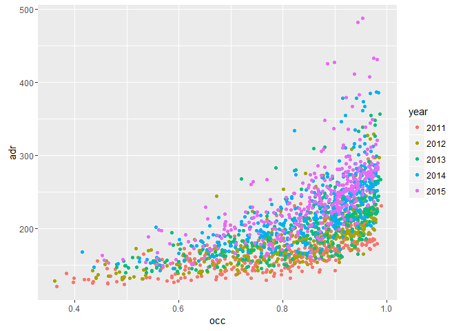

```r
dsfcity_1 %>%
  select(year, occ, adr) %>%
  mutate(year = as.factor(year)) %>%
  ggplot(aes(x=occ, y=adr, color=year)) +
  geom_point()
```

# Surrounding areas

## Initial explorations

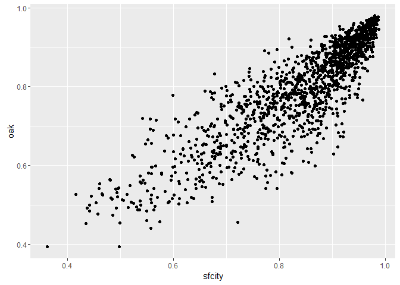

```r
doaksf_1 %>%
  select(geo_ttl, occ, date) %>%
  spread(geo_ttl, occ) %>%
  ggplot(aes(x=sfcity, y=oak)) +
  geom_point()
```

With segment info

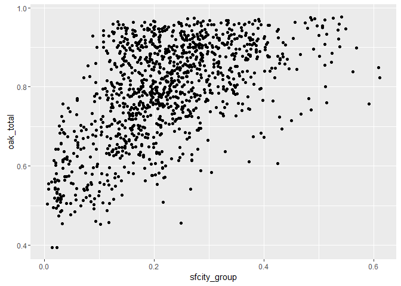

```r
doaksf_seg_1 %>%
  select(geo_ttl, seg, occ, date) %>%
  unite(geoseg, geo_ttl, seg, sep="_", remove=TRUE) %>%
  spread(geoseg, occ) %>%
  ggplot(aes(x=sfcity_group, y=oak_total)) +
  geom_point()
```

## Oak daily as related to SF

Remember, SF segmentation data is missing from 1/10/14 to 9/30/14.

### Occupancy grouped by SF-based categories

Take a look at what Oak occupancy looks like grouped by some of these SF-based categories.

Grouped by SF occupancy category

Overall (so what is oak occupancy, without regard to SF occupancy)

```r
gpoak_a <- doaksf_seg_1 %>%
  filter(geo_ttl == "oak") %>%
  group_by(season1, wday) %>%
  summarise (occ = mean(occ)) %>%
  ungroup() %>%
  spread(wday, occ) %>%
  mutate(sfocccat1 = "allcats") %>%
  select(sfocccat1, everything())

gpoak_a %>%
  kable(digits=c(1,rep(3,7)), format.args = list(big.mark = ","))
```

| sfocccat1 | season1 | Sun | Mon | Tues | Wed | Thurs | Fri | Sat |
| --- | --- | --- | --- | --- | --- | --- | --- | --- |
| allcats | 01_Jan-Dec | 0.572 | 0.681 | 0.733 | 0.738 | 0.693 | 0.626 | 0.7 |
| allcats | 02_Feb-Mar-Apr-May | 0.650 | 0.768 | 0.849 | 0.856 | 0.806 | 0.762 | 0.8 |
| allcats | 03_Jun | 0.751 | 0.871 | 0.928 | 0.937 | 0.896 | 0.852 | 0.9 |
| allcats | 04_Jul-Aug-Sep | 0.774 | 0.856 | 0.905 | 0.908 | 0.876 | 0.876 | 0.9 |
| allcats | 05_Oct | 0.752 | 0.847 | 0.898 | 0.898 | 0.860 | 0.839 | 0.9 |
| allcats | 06_Nov | 0.622 | 0.746 | 0.797 | 0.810 | 0.779 | 0.716 | 0.7 |

```r
gpoak_b <- doaksf_seg_1 %>%
  filter(geo_ttl == "oak") %>%
  group_by(sfocccat1, season1, wday) %>%
  summarise (occ = mean(occ)) %>%
  ungroup() %>%
  spread(wday, occ)

gpoak_b %>%
  kable(digits=c(1,rep(3,7)), format.args = list(big.mark = ","))
```

| sfocccat1 | season1 | Sun | Mon | Tues | Wed | Thurs | Fri | Sat |
| --- | --- | --- | --- | --- | --- | --- | --- | --- |
| (0,0.7] | 01_Jan-Dec | 0.544 | 0.615 | 0.641 | 0.593 | 0.621 | 0.575 | 0.6 |
| (0,0.7] | 02_Feb-Mar-Apr-May | 0.604 | 0.630 | 0.765 | 0.768 | 0.735 | 0.663 | 0.6 |
| (0,0.7] | 04_Jul-Aug-Sep | 0.680 | 0.579 | 0.639 | NA | NA | NA | NA |
| (0,0.7] | 05_Oct | NA | NA | NA | 0.666 | NA | 0.642 | NA |
| (0,0.7] | 06_Nov | 0.545 | 0.590 | 0.562 | 0.531 | 0.627 | NA | 0.6 |
| (0.7,0.8] | 01_Jan-Dec | 0.558 | 0.695 | 0.746 | 0.792 | 0.733 | 0.650 | 0.7 |
| (0.7,0.8] | 02_Feb-Mar-Apr-May | 0.668 | 0.742 | 0.765 | 0.789 | 0.768 | 0.707 | 0.7 |
| (0.7,0.8] | 03_Jun | 0.704 | 0.722 | 0.826 | NA | NA | 0.755 | NA |
| (0.7,0.8] | 04_Jul-Aug-Sep | 0.757 | 0.717 | 0.702 | 0.672 | 0.722 | 0.810 | NA |
| (0.7,0.8] | 05_Oct | 0.719 | 0.838 | 0.894 | NA | 0.713 | 0.627 | 0.7 |
| (0.7,0.8] | 06_Nov | 0.665 | 0.770 | NA | 0.749 | 0.749 | 0.676 | 0.7 |
| (0.8,0.9] | 01_Jan-Dec | 0.636 | 0.682 | 0.808 | 0.833 | 0.687 | 0.668 | 0.7 |
| (0.8,0.9] | 02_Feb-Mar-Apr-May | 0.740 | 0.796 | 0.836 | 0.840 | 0.809 | 0.787 | 0.7 |
| (0.8,0.9] | 03_Jun | 0.759 | 0.858 | 0.874 | 0.873 | 0.853 | 0.822 | 0.8 |
| (0.8,0.9] | 04_Jul-Aug-Sep | 0.768 | 0.846 | 0.846 | 0.777 | 0.853 | 0.829 | 0.8 |
| (0.8,0.9] | 05_Oct | 0.748 | 0.821 | 0.825 | 0.807 | 0.868 | 0.833 | 0.8 |
| (0.8,0.9] | 06_Nov | 0.724 | 0.823 | 0.863 | 0.886 | 0.832 | 0.724 | 0.7 |
| (0.9,0.95] | 01_Jan-Dec | 0.757 | 0.777 | 0.888 | 0.838 | 0.808 | 0.748 | 0.7 |
| (0.9,0.95] | 02_Feb-Mar-Apr-May | 0.759 | 0.850 | 0.883 | 0.875 | 0.850 | 0.844 | 0.9 |
| (0.9,0.95] | 03_Jun | 0.801 | 0.877 | 0.924 | 0.928 | 0.905 | 0.877 | 0.9 |
| (0.9,0.95] | 04_Jul-Aug-Sep | 0.841 | 0.899 | 0.922 | 0.903 | 0.891 | 0.882 | 0.9 |
| (0.9,0.95] | 05_Oct | 0.870 | 0.854 | 0.900 | 0.907 | 0.896 | 0.877 | 0.9 |
| (0.9,0.95] | 06_Nov | NA | 0.850 | 0.905 | 0.921 | 0.850 | 0.787 | 0.9 |
| (0.95,1] | 01_Jan-Dec | NA | 0.912 | 0.883 | 0.893 | 0.872 | NA | NA |
| (0.95,1] | 02_Feb-Mar-Apr-May | NA | 0.936 | 0.929 | 0.916 | 0.906 | NA | 0.9 |
| (0.95,1] | 03_Jun | NA | 0.923 | 0.951 | 0.952 | 0.922 | 0.956 | 0.9 |
| (0.95,1] | 04_Jul-Aug-Sep | 0.822 | 0.920 | 0.955 | 0.953 | 0.936 | 0.940 | 0.9 |
| (0.95,1] | 05_Oct | NA | 0.901 | 0.937 | 0.941 | 0.903 | 0.906 | 0.9 |
| (0.95,1] | 06_Nov | NA | 0.892 | 0.922 | 0.926 | 0.906 | 0.847 | 0.9 |

Combine the tables

```r
gpoak_c <- bind_rows(gpoak_a, gpoak_b)

gpoak_c %>%
  kable(digits=c(1,rep(3,7)), format.args = list(big.mark = ","))
```

| sfocccat1 | season1 | Sun | Mon | Tues | Wed | Thurs | Fri | Sat |
| --- | --- | --- | --- | --- | --- | --- | --- | --- |
| allcats | 01_Jan-Dec | 0.572 | 0.681 | 0.733 | 0.738 | 0.693 | 0.626 | 0.7 |
| allcats | 02_Feb-Mar-Apr-May | 0.650 | 0.768 | 0.849 | 0.856 | 0.806 | 0.762 | 0.8 |
| allcats | 03_Jun | 0.751 | 0.871 | 0.928 | 0.937 | 0.896 | 0.852 | 0.9 |
| allcats | 04_Jul-Aug-Sep | 0.774 | 0.856 | 0.905 | 0.908 | 0.876 | 0.876 | 0.9 |
| allcats | 05_Oct | 0.752 | 0.847 | 0.898 | 0.898 | 0.860 | 0.839 | 0.9 |
| allcats | 06_Nov | 0.622 | 0.746 | 0.797 | 0.810 | 0.779 | 0.716 | 0.7 |
| (0,0.7] | 01_Jan-Dec | 0.544 | 0.615 | 0.641 | 0.593 | 0.621 | 0.575 | 0.6 |
| (0,0.7] | 02_Feb-Mar-Apr-May | 0.604 | 0.630 | 0.765 | 0.768 | 0.735 | 0.663 | 0.6 |
| (0,0.7] | 04_Jul-Aug-Sep | 0.680 | 0.579 | 0.639 | NA | NA | NA | NA |
| (0,0.7] | 05_Oct | NA | NA | NA | 0.666 | NA | 0.642 | NA |
| (0,0.7] | 06_Nov | 0.545 | 0.590 | 0.562 | 0.531 | 0.627 | NA | 0.6 |
| (0.7,0.8] | 01_Jan-Dec | 0.558 | 0.695 | 0.746 | 0.792 | 0.733 | 0.650 | 0.7 |
| (0.7,0.8] | 02_Feb-Mar-Apr-May | 0.668 | 0.742 | 0.765 | 0.789 | 0.768 | 0.707 | 0.7 |
| (0.7,0.8] | 03_Jun | 0.704 | 0.722 | 0.826 | NA | NA | 0.755 | NA |
| (0.7,0.8] | 04_Jul-Aug-Sep | 0.757 | 0.717 | 0.702 | 0.672 | 0.722 | 0.810 | NA |
| (0.7,0.8] | 05_Oct | 0.719 | 0.838 | 0.894 | NA | 0.713 | 0.627 | 0.7 |
| (0.7,0.8] | 06_Nov | 0.665 | 0.770 | NA | 0.749 | 0.749 | 0.676 | 0.7 |
| (0.8,0.9] | 01_Jan-Dec | 0.636 | 0.682 | 0.808 | 0.833 | 0.687 | 0.668 | 0.7 |
| (0.8,0.9] | 02_Feb-Mar-Apr-May | 0.740 | 0.796 | 0.836 | 0.840 | 0.809 | 0.787 | 0.7 |
| (0.8,0.9] | 03_Jun | 0.759 | 0.858 | 0.874 | 0.873 | 0.853 | 0.822 | 0.8 |
| (0.8,0.9] | 04_Jul-Aug-Sep | 0.768 | 0.846 | 0.846 | 0.777 | 0.853 | 0.829 | 0.8 |
| (0.8,0.9] | 05_Oct | 0.748 | 0.821 | 0.825 | 0.807 | 0.868 | 0.833 | 0.8 |
| (0.8,0.9] | 06_Nov | 0.724 | 0.823 | 0.863 | 0.886 | 0.832 | 0.724 | 0.7 |
| (0.9,0.95] | 01_Jan-Dec | 0.757 | 0.777 | 0.888 | 0.838 | 0.808 | 0.748 | 0.7 |
| (0.9,0.95] | 02_Feb-Mar-Apr-May | 0.759 | 0.850 | 0.883 | 0.875 | 0.850 | 0.844 | 0.9 |
| (0.9,0.95] | 03_Jun | 0.801 | 0.877 | 0.924 | 0.928 | 0.905 | 0.877 | 0.9 |
| (0.9,0.95] | 04_Jul-Aug-Sep | 0.841 | 0.899 | 0.922 | 0.903 | 0.891 | 0.882 | 0.9 |
| (0.9,0.95] | 05_Oct | 0.870 | 0.854 | 0.900 | 0.907 | 0.896 | 0.877 | 0.9 |
| (0.9,0.95] | 06_Nov | NA | 0.850 | 0.905 | 0.921 | 0.850 | 0.787 | 0.9 |
| (0.95,1] | 01_Jan-Dec | NA | 0.912 | 0.883 | 0.893 | 0.872 | NA | NA |
| (0.95,1] | 02_Feb-Mar-Apr-May | NA | 0.936 | 0.929 | 0.916 | 0.906 | NA | 0.9 |
| (0.95,1] | 03_Jun | NA | 0.923 | 0.951 | 0.952 | 0.922 | 0.956 | 0.9 |
| (0.95,1] | 04_Jul-Aug-Sep | 0.822 | 0.920 | 0.955 | 0.953 | 0.936 | 0.940 | 0.9 |
| (0.95,1] | 05_Oct | NA | 0.901 | 0.937 | 0.941 | 0.903 | 0.906 | 0.9 |
| (0.95,1] | 06_Nov | NA | 0.892 | 0.922 | 0.926 | 0.906 | 0.847 | 0.9 |

```r
gpoak_d <- gpoak_c %>%
  group_by(season1) %>%
  mutate_each(funs(value = ./.[sfocccat1 == "allcats"]), -sfocccat1, -season1) %>%
  ungroup()

# calculate a mean of the weekdays across each row, removing NAs
gpoak_e <- gpoak_d %>%
  mutate(mean=rowMeans(.[, sapply(., is.numeric)], na.rm=TRUE))

gpoak_e %>%
  kable(digits=c(1,rep(3,7)), format.args = list(big.mark = ","))
```

| sfocccat1 | season1 | Sun | Mon | Tues | Wed | Thurs | Fri | Sat | mean |
| --- | --- | --- | --- | --- | --- | --- | --- | --- | --- |
| allcats | 01_Jan-Dec | 1.000 | 1.000 | 1.000 | 1.000 | 1.000 | 1.000 | 1.0 | 1.000 |
| allcats | 02_Feb-Mar-Apr-May | 1.000 | 1.000 | 1.000 | 1.000 | 1.000 | 1.000 | 1.0 | 1.000 |
| allcats | 03_Jun | 1.000 | 1.000 | 1.000 | 1.000 | 1.000 | 1.000 | 1.0 | 1.000 |
| allcats | 04_Jul-Aug-Sep | 1.000 | 1.000 | 1.000 | 1.000 | 1.000 | 1.000 | 1.0 | 1.000 |
| allcats | 05_Oct | 1.000 | 1.000 | 1.000 | 1.000 | 1.000 | 1.000 | 1.0 | 1.000 |
| allcats | 06_Nov | 1.000 | 1.000 | 1.000 | 1.000 | 1.000 | 1.000 | 1.0 | 1.000 |
| (0,0.7] | 01_Jan-Dec | 0.952 | 0.902 | 0.875 | 0.804 | 0.896 | 0.918 | 0.8 | 0.885 |
| (0,0.7] | 02_Feb-Mar-Apr-May | 0.930 | 0.820 | 0.901 | 0.897 | 0.912 | 0.870 | 0.8 | 0.878 |
| (0,0.7] | 04_Jul-Aug-Sep | 0.878 | 0.677 | 0.706 | NA | NA | NA | NA | 0.754 |
| (0,0.7] | 05_Oct | NA | NA | NA | 0.742 | NA | 0.766 | NA | 0.754 |
| (0,0.7] | 06_Nov | 0.877 | 0.792 | 0.705 | 0.656 | 0.805 | NA | 0.8 | 0.774 |
| (0.7,0.8] | 01_Jan-Dec | 0.976 | 1.019 | 1.017 | 1.074 | 1.058 | 1.039 | 1.0 | 1.026 |
| (0.7,0.8] | 02_Feb-Mar-Apr-May | 1.028 | 0.966 | 0.902 | 0.922 | 0.953 | 0.927 | 0.9 | 0.943 |
| (0.7,0.8] | 03_Jun | 0.937 | 0.830 | 0.890 | NA | NA | 0.886 | NA | 0.886 |
| (0.7,0.8] | 04_Jul-Aug-Sep | 0.977 | 0.838 | 0.776 | 0.740 | 0.825 | 0.926 | NA | 0.847 |
| (0.7,0.8] | 05_Oct | 0.956 | 0.990 | 0.996 | NA | 0.830 | 0.748 | 0.8 | 0.884 |
| (0.7,0.8] | 06_Nov | 1.069 | 1.033 | NA | 0.925 | 0.962 | 0.943 | 0.9 | 0.974 |
| (0.8,0.9] | 01_Jan-Dec | 1.112 | 1.001 | 1.102 | 1.129 | 0.992 | 1.067 | 1.0 | 1.064 |
| (0.8,0.9] | 02_Feb-Mar-Apr-May | 1.138 | 1.037 | 0.985 | 0.981 | 1.004 | 1.032 | 1.0 | 1.020 |
| (0.8,0.9] | 03_Jun | 1.010 | 0.986 | 0.942 | 0.933 | 0.952 | 0.965 | 0.9 | 0.956 |
| (0.8,0.9] | 04_Jul-Aug-Sep | 0.992 | 0.989 | 0.935 | 0.856 | 0.974 | 0.947 | 0.9 | 0.943 |
| (0.8,0.9] | 05_Oct | 0.995 | 0.970 | 0.919 | 0.899 | 1.009 | 0.994 | 0.9 | 0.960 |
| (0.8,0.9] | 06_Nov | 1.165 | 1.103 | 1.083 | 1.093 | 1.068 | 1.011 | 1.0 | 1.072 |
| (0.9,0.95] | 01_Jan-Dec | 1.324 | 1.141 | 1.212 | 1.137 | 1.167 | 1.196 | 1.1 | 1.181 |
| (0.9,0.95] | 02_Feb-Mar-Apr-May | 1.168 | 1.107 | 1.041 | 1.022 | 1.055 | 1.107 | 1.1 | 1.087 |
| (0.9,0.95] | 03_Jun | 1.066 | 1.007 | 0.996 | 0.991 | 1.010 | 1.030 | 1.0 | 1.015 |
| (0.9,0.95] | 04_Jul-Aug-Sep | 1.086 | 1.051 | 1.019 | 0.995 | 1.017 | 1.008 | 1.0 | 1.021 |
| (0.9,0.95] | 05_Oct | 1.157 | 1.009 | 1.003 | 1.010 | 1.042 | 1.045 | 1.0 | 1.036 |
| (0.9,0.95] | 06_Nov | NA | 1.139 | 1.136 | 1.137 | 1.092 | 1.099 | 1.2 | 1.128 |
| (0.95,1] | 01_Jan-Dec | NA | 1.339 | 1.204 | 1.211 | 1.258 | NA | NA | 1.253 |
| (0.95,1] | 02_Feb-Mar-Apr-May | NA | 1.219 | 1.094 | 1.070 | 1.124 | NA | 1.2 | 1.138 |
| (0.95,1] | 03_Jun | NA | 1.060 | 1.025 | 1.016 | 1.029 | 1.122 | 1.1 | 1.053 |
| (0.95,1] | 04_Jul-Aug-Sep | 1.062 | 1.075 | 1.055 | 1.050 | 1.069 | 1.073 | 1.0 | 1.059 |
| (0.95,1] | 05_Oct | NA | 1.064 | 1.044 | 1.048 | 1.051 | 1.081 | 1.0 | 1.055 |
| (0.95,1] | 06_Nov | NA | 1.196 | 1.157 | 1.142 | 1.163 | 1.182 | 1.2 | 1.180 |

Grouped by SF group occupancy contribution

Overall (so what is oak occupancy, without regard to SF occupancy)

```r
gpoak_a_2 <- doaksf_seg_1 %>%
  filter(geo_ttl == "oak") %>%
  group_by(season1, wday) %>%
  summarise (occ = mean(occ)) %>%
  ungroup() %>%
  spread(wday, occ) %>%
  mutate(sfgroupcat1 = "allcats") %>%
  select(sfgroupcat1, everything())

gpoak_a_2 %>%
  kable(digits=c(1,rep(3,7)), format.args = list(big.mark = ","))
```

| sfgroupcat1 | season1 | Sun | Mon | Tues | Wed | Thurs | Fri | Sat |
| --- | --- | --- | --- | --- | --- | --- | --- | --- |
| allcats | 01_Jan-Dec | 0.572 | 0.681 | 0.733 | 0.738 | 0.693 | 0.626 | 0.7 |
| allcats | 02_Feb-Mar-Apr-May | 0.650 | 0.768 | 0.849 | 0.856 | 0.806 | 0.762 | 0.8 |
| allcats | 03_Jun | 0.751 | 0.871 | 0.928 | 0.937 | 0.896 | 0.852 | 0.9 |
| allcats | 04_Jul-Aug-Sep | 0.774 | 0.856 | 0.905 | 0.908 | 0.876 | 0.876 | 0.9 |
| allcats | 05_Oct | 0.752 | 0.847 | 0.898 | 0.898 | 0.860 | 0.839 | 0.9 |
| allcats | 06_Nov | 0.622 | 0.746 | 0.797 | 0.810 | 0.779 | 0.716 | 0.7 |

```r
gpoak_b_2 <- doaksf_seg_1 %>%
  filter(geo_ttl == "oak") %>%
  group_by(sfgroupcat1, season1, wday) %>%
  summarise (occ = mean(occ)) %>%
  ungroup() %>%
  spread(wday, occ)

gpoak_b_2 %>%
  kable(digits=c(1,rep(3,7)), format.args = list(big.mark = ","))
```

| sfgroupcat1 | season1 | Sun | Mon | Tues | Wed | Thurs | Fri | Sat |
| --- | --- | --- | --- | --- | --- | --- | --- | --- |
| (0,0.2] | 01_Jan-Dec | 0.552 | 0.628 | 0.658 | 0.650 | 0.654 | 0.613 | 0.6 |
| (0,0.2] | 02_Feb-Mar-Apr-May | 0.629 | 0.677 | 0.779 | 0.800 | 0.775 | 0.730 | 0.7 |
| (0,0.2] | 03_Jun | 0.700 | NA | 0.885 | NA | NA | 0.800 | 0.9 |
| (0,0.2] | 04_Jul-Aug-Sep | 0.761 | 0.800 | 0.865 | 0.878 | 0.848 | 0.872 | 0.9 |
| (0,0.2] | 05_Oct | 0.744 | NA | NA | 0.666 | NA | 0.793 | 0.8 |
| (0,0.2] | 06_Nov | 0.545 | 0.590 | 0.562 | 0.531 | 0.651 | 0.669 | 0.6 |
| (0.2,0.4] | 01_Jan-Dec | 0.593 | 0.745 | 0.830 | 0.828 | 0.752 | 0.639 | 0.7 |
| (0.2,0.4] | 02_Feb-Mar-Apr-May | 0.675 | 0.792 | 0.858 | 0.858 | 0.811 | 0.798 | 0.8 |
| (0.2,0.4] | 03_Jun | 0.767 | 0.876 | 0.934 | 0.937 | 0.895 | 0.856 | 0.9 |
| (0.2,0.4] | 04_Jul-Aug-Sep | 0.769 | 0.891 | 0.933 | 0.922 | 0.891 | 0.867 | 0.9 |
| (0.2,0.4] | 05_Oct | 0.748 | 0.835 | 0.890 | 0.906 | 0.862 | 0.869 | 0.9 |
| (0.2,0.4] | 06_Nov | 0.695 | 0.819 | 0.898 | 0.899 | 0.825 | 0.720 | 0.8 |
| (0.4,0.5] | 01_Jan-Dec | NA | NA | NA | 0.893 | 0.844 | NA | 0.8 |
| (0.4,0.5] | 02_Feb-Mar-Apr-May | 0.685 | 0.868 | 0.899 | NA | NA | 0.779 | 0.9 |
| (0.4,0.5] | 03_Jun | NA | NA | NA | NA | NA | 0.956 | NA |
| (0.4,0.5] | 04_Jul-Aug-Sep | 0.824 | 0.900 | 0.926 | 0.939 | 0.958 | NA | NA |
| (0.4,0.5] | 05_Oct | 0.806 | 0.846 | 0.884 | 0.928 | 0.923 | 0.872 | NA |
| (0.4,0.5] | 06_Nov | 0.724 | 0.885 | NA | NA | 0.906 | 0.843 | 0.9 |
| (0.5,1] | 01_Jan-Dec | 0.757 | 0.902 | NA | NA | 0.862 | 0.792 | 0.8 |
| (0.5,1] | 02_Feb-Mar-Apr-May | NA | NA | 0.877 | 0.899 | 0.838 | NA | NA |
| (0.5,1] | 04_Jul-Aug-Sep | 0.843 | 0.947 | 0.975 | 0.973 | NA | NA | NA |
| (0.5,1] | 05_Oct | NA | 0.903 | 0.945 | 0.950 | NA | NA | NA |
| (0.5,1] | 06_Nov | NA | NA | 0.954 | 0.943 | NA | NA | NA |
| NA | 01_Jan-Dec | 0.565 | 0.720 | 0.795 | 0.732 | 0.679 | 0.602 | 0.6 |
| NA | 02_Feb-Mar-Apr-May | 0.658 | 0.786 | 0.872 | 0.876 | 0.820 | 0.778 | 0.8 |
| NA | 03_Jun | 0.738 | 0.856 | 0.933 | 0.935 | 0.901 | 0.869 | 0.9 |
| NA | 04_Jul-Aug-Sep | 0.792 | 0.883 | 0.920 | 0.920 | 0.885 | 0.891 | 0.9 |
| NA | 05_Oct | 0.712 | 0.828 | 0.865 | 0.833 | 0.691 | 0.627 | NA |

Combine the tables

```r
gpoak_c_2 <- bind_rows(gpoak_a_2, gpoak_b_2)

gpoak_c_2 %>%
  kable(digits=c(1,rep(3,7)), format.args = list(big.mark = ","))
```

| sfgroupcat1 | season1 | Sun | Mon | Tues | Wed | Thurs | Fri | Sat |
| --- | --- | --- | --- | --- | --- | --- | --- | --- |
| allcats | 01_Jan-Dec | 0.572 | 0.681 | 0.733 | 0.738 | 0.693 | 0.626 | 0.7 |
| allcats | 02_Feb-Mar-Apr-May | 0.650 | 0.768 | 0.849 | 0.856 | 0.806 | 0.762 | 0.8 |
| allcats | 03_Jun | 0.751 | 0.871 | 0.928 | 0.937 | 0.896 | 0.852 | 0.9 |
| allcats | 04_Jul-Aug-Sep | 0.774 | 0.856 | 0.905 | 0.908 | 0.876 | 0.876 | 0.9 |
| allcats | 05_Oct | 0.752 | 0.847 | 0.898 | 0.898 | 0.860 | 0.839 | 0.9 |
| allcats | 06_Nov | 0.622 | 0.746 | 0.797 | 0.810 | 0.779 | 0.716 | 0.7 |
| (0,0.2] | 01_Jan-Dec | 0.552 | 0.628 | 0.658 | 0.650 | 0.654 | 0.613 | 0.6 |
| (0,0.2] | 02_Feb-Mar-Apr-May | 0.629 | 0.677 | 0.779 | 0.800 | 0.775 | 0.730 | 0.7 |
| (0,0.2] | 03_Jun | 0.700 | NA | 0.885 | NA | NA | 0.800 | 0.9 |
| (0,0.2] | 04_Jul-Aug-Sep | 0.761 | 0.800 | 0.865 | 0.878 | 0.848 | 0.872 | 0.9 |
| (0,0.2] | 05_Oct | 0.744 | NA | NA | 0.666 | NA | 0.793 | 0.8 |
| (0,0.2] | 06_Nov | 0.545 | 0.590 | 0.562 | 0.531 | 0.651 | 0.669 | 0.6 |
| (0.2,0.4] | 01_Jan-Dec | 0.593 | 0.745 | 0.830 | 0.828 | 0.752 | 0.639 | 0.7 |
| (0.2,0.4] | 02_Feb-Mar-Apr-May | 0.675 | 0.792 | 0.858 | 0.858 | 0.811 | 0.798 | 0.8 |
| (0.2,0.4] | 03_Jun | 0.767 | 0.876 | 0.934 | 0.937 | 0.895 | 0.856 | 0.9 |
| (0.2,0.4] | 04_Jul-Aug-Sep | 0.769 | 0.891 | 0.933 | 0.922 | 0.891 | 0.867 | 0.9 |
| (0.2,0.4] | 05_Oct | 0.748 | 0.835 | 0.890 | 0.906 | 0.862 | 0.869 | 0.9 |
| (0.2,0.4] | 06_Nov | 0.695 | 0.819 | 0.898 | 0.899 | 0.825 | 0.720 | 0.8 |
| (0.4,0.5] | 01_Jan-Dec | NA | NA | NA | 0.893 | 0.844 | NA | 0.8 |
| (0.4,0.5] | 02_Feb-Mar-Apr-May | 0.685 | 0.868 | 0.899 | NA | NA | 0.779 | 0.9 |
| (0.4,0.5] | 03_Jun | NA | NA | NA | NA | NA | 0.956 | NA |
| (0.4,0.5] | 04_Jul-Aug-Sep | 0.824 | 0.900 | 0.926 | 0.939 | 0.958 | NA | NA |
| (0.4,0.5] | 05_Oct | 0.806 | 0.846 | 0.884 | 0.928 | 0.923 | 0.872 | NA |
| (0.4,0.5] | 06_Nov | 0.724 | 0.885 | NA | NA | 0.906 | 0.843 | 0.9 |
| (0.5,1] | 01_Jan-Dec | 0.757 | 0.902 | NA | NA | 0.862 | 0.792 | 0.8 |
| (0.5,1] | 02_Feb-Mar-Apr-May | NA | NA | 0.877 | 0.899 | 0.838 | NA | NA |
| (0.5,1] | 04_Jul-Aug-Sep | 0.843 | 0.947 | 0.975 | 0.973 | NA | NA | NA |
| (0.5,1] | 05_Oct | NA | 0.903 | 0.945 | 0.950 | NA | NA | NA |
| (0.5,1] | 06_Nov | NA | NA | 0.954 | 0.943 | NA | NA | NA |
| NA | 01_Jan-Dec | 0.565 | 0.720 | 0.795 | 0.732 | 0.679 | 0.602 | 0.6 |
| NA | 02_Feb-Mar-Apr-May | 0.658 | 0.786 | 0.872 | 0.876 | 0.820 | 0.778 | 0.8 |
| NA | 03_Jun | 0.738 | 0.856 | 0.933 | 0.935 | 0.901 | 0.869 | 0.9 |
| NA | 04_Jul-Aug-Sep | 0.792 | 0.883 | 0.920 | 0.920 | 0.885 | 0.891 | 0.9 |
| NA | 05_Oct | 0.712 | 0.828 | 0.865 | 0.833 | 0.691 | 0.627 | NA |

```r
# following doesn't work because the Jun season (and maybe others) are missing from
# at least one of the category groupings

# gpoak_d_2 <- gpoak_c_2 %>%
#   group_by(season1) %>%
#   mutate_each(funs(value = ./.[sfgroupcat1 == "allcats"]), -sfgroupcat1, -season1) %>%
#   ungroup()
#
# # calculate a mean of the weekdays across each row, removing NAs
# gpoak_e_2 <- gpoak_d_2 %>%
#   mutate(mean=rowMeans(.[, sapply(., is.numeric)], na.rm=TRUE))
#
# gpoak_e_2 %>%
#   kable(digits=c(1,rep(3,7)), format.args = list(big.mark = ","))
```